# Model Comparison: Spatial vs Plant Blocking for Differential Expression

Fausto Rodriguez Zapata

2025-12-24

# Overview

This analysis compares two mixed-effects model specifications for differential gene expression analysis, focusing on **Inv4m genotype effects**. The goal is to determine whether accounting for within-plant leaf correlation (plant blocking) vs. spatial field structure (row/column terms) substantively changes inference about the Inv4m inversion.

## Model Specifications

### Model A: Spatial Correction Model (Current Approach)

For log-transformed response $Y_{ijrs}$ (gene expression) from leaf stage $s$, in plant $r$, under phosphorus treatment $i$, with Inv4m genotype $j$:

$$\begin{aligned}
Y_{ijrs} = {}& \beta_0 + \beta_1 \text{Row}_\ell + \beta_2
\text{Leaf}_s + \beta_3 \text{P}_i + \beta_4 \text{Inv4m}_j \\
& + \beta_5 [\text{Leaf} \times \text{P}]_{si} + \beta_6 [\text{P}
\times \text{Inv4m}]_{ij} \\
& + \beta_7 [\text{Leaf} \times \text{Inv4m}]_{sj} + u_c +
\varepsilon_{ijrs}
\end{aligned}$$

with random effect $u_c \sim \mathcal{N}(0, \sigma^2_u)$ for column nested within treatment.

### Model B: Plant Blocking Model (New Approach)

$$\begin{aligned}
Y_{ijrs} = {}& \beta_0 + \beta_2 \text{Leaf}_s + \beta_3 \text{P}_i
+ \beta_4 \text{Inv4m}_j \\
& + \beta_5 [\text{Leaf} \times \text{P}]_{si} + \beta_6 [\text{P}
\times \text{Inv4m}]_{ij} \\
& + \beta_7 [\text{Leaf} \times \text{Inv4m}]_{sj} + u_r +
\varepsilon_{ijrs}
\end{aligned}$$

with random effect $u_r \sim \mathcal{N}(0, \sigma^2_u)$ for plant identity.

**Key difference**: Model B removes the fixed Row effect ($\beta_1$) and replaces column blocking with plant blocking to account for within-plant correlation among leaves.

## Coefficients of Interest

Focus on three Inv4m-related effects:

- $\beta_4$: `Genotype` - Main effect of Inv4m
- $\beta_6$: `Genotype:Treatment-P` - Inv4m modifies phosphorus response
- $\beta_7$: `Genotype:leaf_tissue_c` - Inv4m effect varies with leaf development

# Libraries

```r
library(edgeR)
library(limma)
library(dplyr)
library(tidyr)
library(tibble)
library(ggplot2)
library(ggpubr)
```

# Data Import

## Load Expression Counts

```r
counts <- read.csv(file.path(paths$data, "inv4mRNAseq_gene_sample_exp.csv"))

cat("Loaded expression data\n")
```

```
## Loaded expression data
```

```r
cat("  Dimensions:", dim(counts), "\n")
```

```
##   Dimensions: 39756 62
```

```r
cat("  Genes:", nrow(counts), "\n")
```

```
##   Genes: 39756
```

```r
cat("  Samples:", ncol(counts) - 2, "\n")
```

```
##   Samples: 60
```

## Load Sample Metadata

```r
sampleInfo <- read.csv(file.path(paths$data, "PSU2022_metadata.csv"))

# Recode Treatment: High_P -> +P, Low_P -> -P
sampleInfo$Treatment <- factor(sampleInfo$Treatment,
                               levels = c("High_P", "Low_P"),
                               labels = c("+P", "-P"))

# Recode Genotype: CTRL -> CTRL, INV4m -> Inv4m
sampleInfo$Genotype <- factor(sampleInfo$Genotype,
                              levels = c("CTRL", "INV4m"),
                              labels = c("CTRL", "Inv4m"))

# RNA_Plant already exists in new metadata (actual plant field IDs)

cat("\nSample metadata loaded\n")
```

```
##
## Sample metadata loaded
```

```r
cat("  Total samples:", nrow(sampleInfo), "\n")
```

```
##   Total samples: 64
```

```r
cat("  Genotypes:", paste(unique(sampleInfo$Genotype), collapse = ", "), "\n")
```

```
##   Genotypes: CTRL, Inv4m
```

```r
cat("  Treatments:", paste(unique(sampleInfo$Treatment), collapse = ", "), "\n")
```

```
##   Treatments: -P, +P
```

## Prepare Count Matrix

```r
# Extract gene IDs
gene_ids <- data.frame(gene = counts[, 2])

# Convert to matrix and set row names
counts <- as.matrix(counts[, -c(1:2)])
rownames(counts) <- gene_ids$gene

# Get sample names from count matrix columns
sampleNames <- colnames(counts)

# Reorder metadata to match count matrix column order
sampleInfo <- sampleInfo[match(sampleNames, sampleInfo$library), ]

cat("\nSample matching verified:", all(sampleNames %in% sampleInfo$library), "\n")
```

```
##
## Sample matching verified: TRUE
```

```r
cat("Count matrix: ", nrow(counts), "genes x", ncol(counts), "samples\n")
```

```
## Count matrix:  39756 genes x 60 samples
```

## Create DGEList Object

```r
# Create DGEList with counts and sample information
y <- DGEList(counts = counts, samples = sampleInfo)

# Define groups from Treatment and Genotype interaction
y$group <- interaction(y$samples$Treatment, y$samples$Genotype)

cat("\nDGEList object created\n")
```

```
##
## DGEList object created
```

```r
cat("Groups:", paste(levels(y$group), collapse = ", "), "\n")
```

```
## Groups: +P.CTRL, -P.CTRL, +P.Inv4m, -P.Inv4m
```

# Expression Filtering and Sample QC

## Filter Genes by Expression Level

```r
# Keep genes with sufficient expression
keep <- filterByExpr(y, group = y$group)
y_filtered <- y[keep, ]

cat("\nExpression filtering:\n")
```

```
##
## Expression filtering:
```

```r
cat("  Genes before:", nrow(y), "\n")
```

```
##   Genes before: 39756
```

```r
cat("  Genes after:", nrow(y_filtered), "\n")
```

```
##   Genes after: 24249
```

```r
cat("  Genes removed:", sum(!keep), "\n")
```

```
##   Genes removed: 15507
```

## Filter Low Quality Libraries

Samples with library size < 20 million reads are considered low quality.

```r
# Flag low count libraries
y_filtered$samples$lowCount <- y_filtered$samples$lib.size < 2e7

# Remove low quality samples
y_filtered_bySample <- y_filtered[, !y_filtered$samples$lowCount]

cat("\nLibrary size filtering:\n")
```

```
##
## Library size filtering:
```

```r
cat("  Low quality samples removed:", sum(y_filtered$samples$lowCount), "\n")
```

```
##   Low quality samples removed: 17
```

```r
cat("  Samples retained:", ncol(y_filtered_bySample), "\n")
```

```
##   Samples retained: 43
```

## Sample Distribution Verification

```r
d <- y_filtered_bySample$samples

cat("\n=== Sample Distribution After QC ===\n")
```

```
##
## === Sample Distribution After QC ===
```

```r
cat("\n-- Treatment x Genotype --\n")
```

```
##
## -- Treatment x Genotype --
```

```r
print(table(d$Treatment, d$Genotype))
```

```
##
##      CTRL Inv4m
##   +P   12    12
##   -P    8    11
```

```r
cat("\n-- Leaf tissue distribution --\n")
```

```
##
## -- Leaf tissue distribution --
```

```r
print(table(d$leaf_tissue))
```

```
##
##  1  2  3  4
## 11 11 11 10
```

# Construct Plant_ID Variable

Create the plant identifier for Model B blocking structure.

```r
# Derive PlantRep within each Treatment-Genotype combination
d <- d %>%
  group_by(Treatment, Genotype) %>%
  mutate(PlantRep = match(RNA_Plant, unique(RNA_Plant))) %>%
  ungroup()

# Create Plant_ID (should yield 16 unique levels)
d$Plant_ID <- factor(paste(d$Treatment, d$Genotype, d$PlantRep, sep = "_"))

cat("\nPlant_ID construction:\n")
```

```
##
## Plant_ID construction:
```

```r
cat("  Unique plants:", length(unique(d$Plant_ID)), "\n")
```

```
##   Unique plants: 13
```

```r
cat("  Plant_ID levels:\n")
```

```
##   Plant_ID levels:
```

```r
print(table(d$Plant_ID))
```

```
##
##  -P_CTRL_1  -P_CTRL_2  -P_CTRL_3 -P_Inv4m_1 -P_Inv4m_2 -P_Inv4m_3 -P_Inv4m_4
##          4          1          3          4          2          1          4
##  +P_CTRL_1  +P_CTRL_2  +P_CTRL_3 +P_Inv4m_1 +P_Inv4m_2 +P_Inv4m_3
##          4          4          4          4          4          4
```

## Center Leaf Tissue Variable

```r
# Center the continuous leaf stage variable
d$leaf_tissue_c <- scale(d$leaf_tissue, center = TRUE, scale = FALSE)

cat("\nLeaf tissue centered: mean =", round(mean(d$leaf_tissue), 2), "\n")
```

```
##
## Leaf tissue centered: mean = 2.47
```

# Normalization

Apply TMM normalization to both models using the same filtered gene set.

```r
# Calculate TMM normalization factors
y_filtered_bySample <- calcNormFactors(y_filtered_bySample)

cat("TMM normalization factors range:",
    round(range(y_filtered_bySample$samples$norm.factors), 4), "\n")
```

```
## TMM normalization factors range: 0.839 1.1364
```

# Model A: Spatial Correction Model

## Design Matrix

```r
# Define block: column nested within treatment
block_spatial <- interaction(d$Treatment, d$Plot_Column)

# Design matrix with Plot_Row fixed effect
design_spatial <- model.matrix(
  ~ Plot_Row + leaf_tissue_c * Treatment + Genotype * Treatment + Genotype * leaf_tissue_c,
  data = d
)

cat("Model A Design Matrix:\n")
```

```
## Model A Design Matrix:
```

```r
cat("  Samples:", nrow(design_spatial), "\n")
```

```
##   Samples: 43
```

```r
cat("  Coefficients:", ncol(design_spatial), "\n")
```

```
##   Coefficients: 8
```

```r
cat("  Coefficient names:\n")
```

```
##   Coefficient names:
```

```r
print(colnames(design_spatial))
```

```
## [1] "(Intercept)"                 "Plot_Row"
## [3] "leaf_tissue_c"               "Treatment-P"
## [5] "GenotypeInv4m"               "leaf_tissue_c:Treatment-P"
## [7] "Treatment-P:GenotypeInv4m"   "leaf_tissue_c:GenotypeInv4m"
```

```r
cat("\nSpatial blocking structure:\n")
```

```
##
## Spatial blocking structure:
```

```r
cat("  Unique blocks:", length(unique(block_spatial)), "\n")
```

```
##   Unique blocks: 7
```

## Voom Transformation and Model Fitting

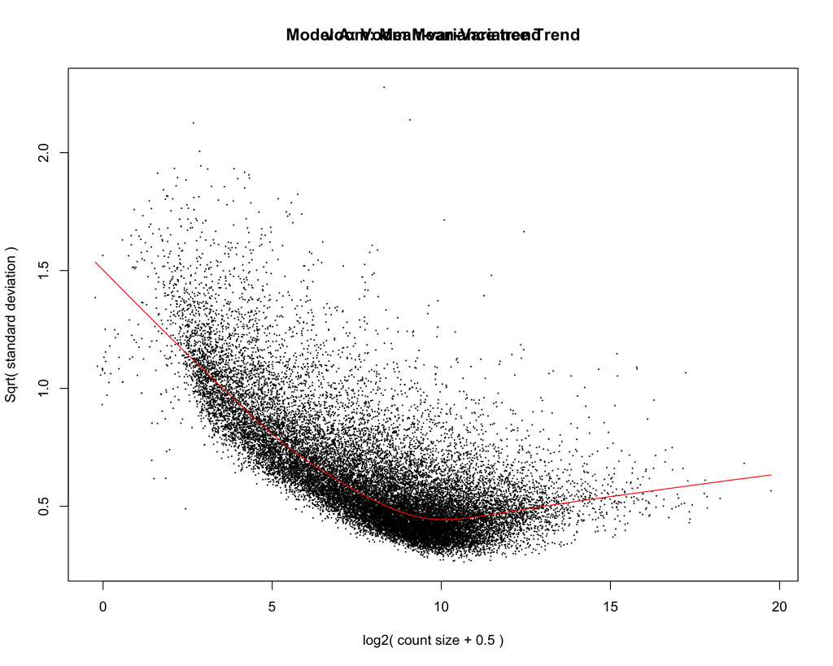

```r
# Voom transformation
voomR_spatial <- voom(y_filtered_bySample, design = design_spatial, plot = TRUE)
title("Model A: Voom Mean-Variance Trend")
```

```r
# Estimate within-block correlation
corfit_spatial <- duplicateCorrelation(voomR_spatial, design_spatial, block = block_spatial)

cat("\nModel A: Spatial blocking correlation\n")
```

```
##
## Model A: Spatial blocking correlation
```

```r
cat("  Consensus correlation:", round(corfit_spatial$consensus.correlation, 4), "\n")
```

```
##   Consensus correlation: 0.1144
```

```r
# Fit linear model with block correlation
fit_spatial <- lmFit(voomR_spatial, design_spatial,
                     block = block_spatial,
                     correlation = corfit_spatial$consensus.correlation)

# Empirical Bayes moderation
eb_spatial <- eBayes(fit_spatial)

cat("Model A fitted:", nrow(eb_spatial$coefficients), "genes\n")
```

```
## Model A fitted: 24249 genes
```

# Model B: Plant Blocking Model

## Design Matrix

```r
# Design matrix WITHOUT Plot_Row (absorbed into plant random effect)
design_plant <- model.matrix(
  ~ leaf_tissue_c * Treatment + Genotype * Treatment + Genotype * leaf_tissue_c,
  data = d
)

cat("Model B Design Matrix:\n")
```

```
## Model B Design Matrix:
```

```r
cat("  Samples:", nrow(design_plant), "\n")
```

```
##   Samples: 43
```

```r
cat("  Coefficients:", ncol(design_plant), "\n")
```

```
##   Coefficients: 7
```

```r
cat("  Coefficient names:\n")
```

```
##   Coefficient names:
```

```r
print(colnames(design_plant))
```

```
## [1] "(Intercept)"                 "leaf_tissue_c"
## [3] "Treatment-P"                 "GenotypeInv4m"
## [5] "leaf_tissue_c:Treatment-P"   "Treatment-P:GenotypeInv4m"
## [7] "leaf_tissue_c:GenotypeInv4m"
```

```r
cat("\nPlant blocking structure:\n")
```

```
##
## Plant blocking structure:
```

```r
cat("  Unique plants:", length(unique(d$Plant_ID)), "\n")
```

```
##   Unique plants: 13
```

## Voom Transformation and Model Fitting

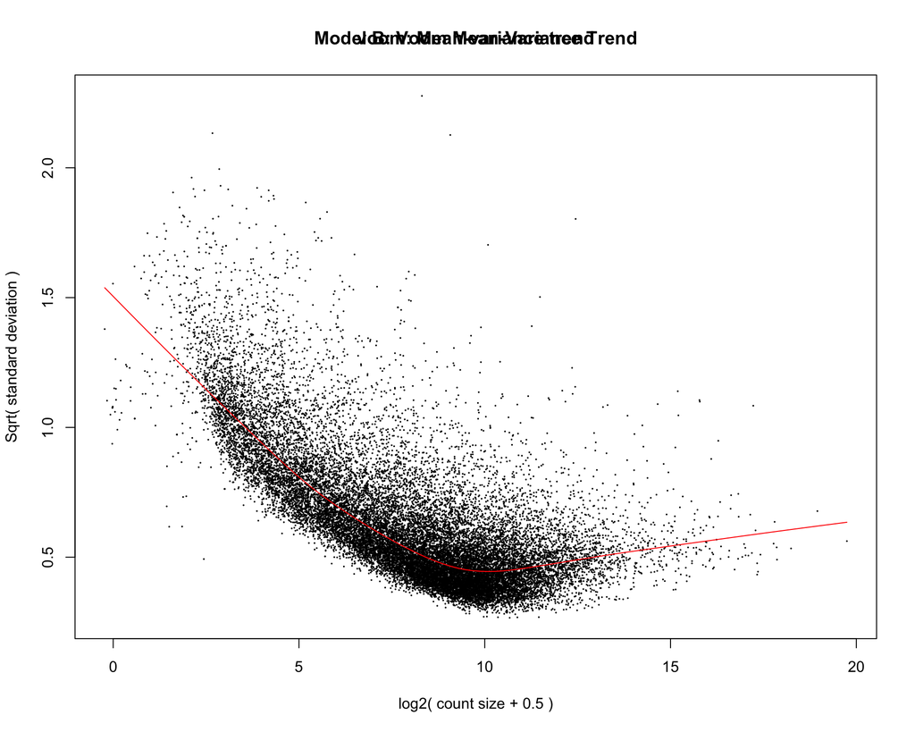

```r
# Voom transformation (same normalization, different design)
voomR_plant <- voom(y_filtered_bySample, design = design_plant, plot = TRUE)
title("Model B: Voom Mean-Variance Trend")
```

```r
# Estimate within-plant correlation
corfit_plant <- duplicateCorrelation(voomR_plant, design_plant, block = d$Plant_ID)

cat("\nModel B: Plant blocking correlation\n")
```

```
##
## Model B: Plant blocking correlation
```

```r
cat("  Consensus correlation:", round(corfit_plant$consensus.correlation, 4), "\n")
```

```
##   Consensus correlation: 0.133
```

```r
# Fit linear model with plant blocking
fit_plant <- lmFit(voomR_plant, design_plant,
                   block = d$Plant_ID,
                   correlation = corfit_plant$consensus.correlation)

# Empirical Bayes moderation
eb_plant <- eBayes(fit_plant)

cat("Model B fitted:", nrow(eb_plant$coefficients), "genes\n")
```

```
## Model B fitted: 24249 genes
```

# Extract Inv4m-Related DEG Results

## Define Coefficient Names

```r
# Model A coefficient names for Inv4m effects
coef_spatial <- list(
  genotype = "GenotypeInv4m",
  genotype_trt = "Treatment-P:GenotypeInv4m",
  genotype_leaf = "leaf_tissue_c:GenotypeInv4m"
)

# Model B coefficient names for Inv4m effects
coef_plant <- list(
  genotype = "GenotypeInv4m",
  genotype_trt = "Treatment-P:GenotypeInv4m",
  genotype_leaf = "leaf_tissue_c:GenotypeInv4m"
)

# Verify coefficients exist
cat("Model A available coefficients:\n")
```

```
## Model A available coefficients:
```

```r
print(colnames(coef(eb_spatial)))
```

```
## [1] "(Intercept)"                 "Plot_Row"
## [3] "leaf_tissue_c"               "Treatment-P"
## [5] "GenotypeInv4m"               "leaf_tissue_c:Treatment-P"
## [7] "Treatment-P:GenotypeInv4m"   "leaf_tissue_c:GenotypeInv4m"
```

```r
cat("\nModel B available coefficients:\n")
```

```
##
## Model B available coefficients:
```

```r
print(colnames(coef(eb_plant)))
```

```
## [1] "(Intercept)"                 "leaf_tissue_c"
## [3] "Treatment-P"                 "GenotypeInv4m"
## [5] "leaf_tissue_c:Treatment-P"   "Treatment-P:GenotypeInv4m"
## [7] "leaf_tissue_c:GenotypeInv4m"
```

## Extract Results

```r
fdr_threshold <- 0.05

# Function to extract DEG results for a coefficient
extract_deg_results <- function(eb_fit, coef_name, fdr = 0.05) {
  tt <- topTable(eb_fit, coef = coef_name, number = Inf, sort.by = "none")
  tt$gene <- rownames(tt)
  tt$is_sig <- tt$adj.P.Val < fdr
  return(tt)
}

# Model A results
results_spatial <- list(
  genotype = extract_deg_results(eb_spatial, coef_spatial$genotype),
  genotype_trt = extract_deg_results(eb_spatial, coef_spatial$genotype_trt),
  genotype_leaf = extract_deg_results(eb_spatial, coef_spatial$genotype_leaf)
)

# Model B results
results_plant <- list(
  genotype = extract_deg_results(eb_plant, coef_plant$genotype),
  genotype_trt = extract_deg_results(eb_plant, coef_plant$genotype_trt),
  genotype_leaf = extract_deg_results(eb_plant, coef_plant$genotype_leaf)
)

# Identify significant genes
sig_spatial <- lapply(results_spatial, function(x) x$gene[x$is_sig])
sig_plant <- lapply(results_plant, function(x) x$gene[x$is_sig])

cat("\nDEGs detected (FDR < 0.05):\n")
```

```
##
## DEGs detected (FDR < 0.05):
```

```r
cat("\n-- Model A (Spatial) --\n")
```

```
##
## -- Model A (Spatial) --
```

```r
sapply(sig_spatial, length)
```

```
##      genotype  genotype_trt genotype_leaf
##           603             3             2
```

```r
cat("\n-- Model B (Plant) --\n")
```

```
##
## -- Model B (Plant) --
```

```r
sapply(sig_plant, length)
```

```
##      genotype  genotype_trt genotype_leaf
##           470             1             1
```

# Comparison Metrics

## DEG Count Comparison

```r
comparison_counts <- tibble(
  coefficient = c("Genotype", "Genotype:Treatment", "Genotype:Leaf"),
  n_spatial = c(length(sig_spatial$genotype),
                length(sig_spatial$genotype_trt),
                length(sig_spatial$genotype_leaf)),
  n_plant = c(length(sig_plant$genotype),
              length(sig_plant$genotype_trt),
              length(sig_plant$genotype_leaf))
) %>%
  mutate(
    difference = n_spatial - n_plant,
    pct_change = round(100 * (n_plant - n_spatial) / n_spatial, 1)
  )

cat("\n=== DEG Count Comparison ===\n")
```

```
##
## === DEG Count Comparison ===
```

```r
print(comparison_counts)
```

```
## # A tibble: 3 × 5
##   coefficient        n_spatial n_plant difference pct_change
##   <chr>                  <int>   <int>      <int>      <dbl>
## 1 Genotype                 603     470        133      -22.1
## 2 Genotype:Treatment         3       1          2      -66.7
## 3 Genotype:Leaf              2       1          1      -50
```

```r
# Save comparison counts
write.csv(comparison_counts,
          file.path(paths$intermediate, "deg_counts_comparison.csv"),
          row.names = FALSE)
```

## Overlap Analysis

```r
# Calculate overlaps for each coefficient
calculate_overlap <- function(sig_a, sig_b, coef_name) {
  both <- intersect(sig_a, sig_b)
  spatial_only <- setdiff(sig_a, sig_b)
  plant_only <- setdiff(sig_b, sig_a)

  tibble(
    coefficient = coef_name,
    n_both = length(both),
    n_spatial_only = length(spatial_only),
    n_plant_only = length(plant_only),
    jaccard = length(both) / (length(both) + length(spatial_only) + length(plant_only))
  )
}

overlap_summary <- bind_rows(
  calculate_overlap(sig_spatial$genotype, sig_plant$genotype, "Genotype"),
  calculate_overlap(sig_spatial$genotype_trt, sig_plant$genotype_trt, "Genotype:Treatment"),
  calculate_overlap(sig_spatial$genotype_leaf, sig_plant$genotype_leaf, "Genotype:Leaf")
)

cat("\n=== Overlap Summary ===\n")
```

```
##
## === Overlap Summary ===
```

```r
print(overlap_summary)
```

```
## # A tibble: 3 × 5
##   coefficient        n_both n_spatial_only n_plant_only jaccard
##   <chr>               <int>          <int>        <int>   <dbl>
## 1 Genotype              465            138            5   0.765
## 2 Genotype:Treatment      1              2            0   0.333
## 3 Genotype:Leaf           1              1            0   0.5
```

```r
# Save overlap summary
write.csv(overlap_summary,
          file.path(paths$intermediate, "deg_overlap_summary.csv"),
          row.names = FALSE)
```

## Overlap Visualization

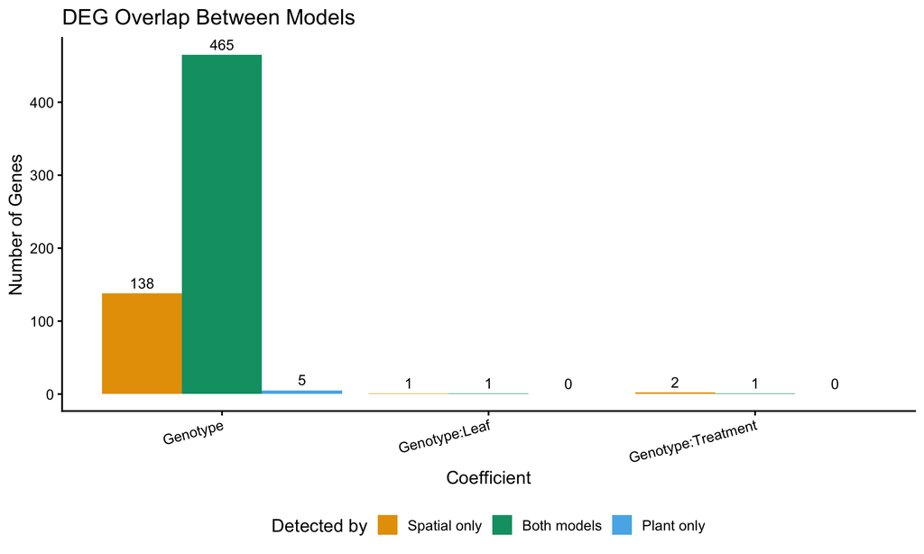

```r
# Create bar plot showing overlap categories
overlap_long <- overlap_summary %>%
  pivot_longer(
    cols = c(n_both, n_spatial_only, n_plant_only),
    names_to = "category",
    values_to = "count"
  ) %>%
  mutate(
    category = factor(category,
                      levels = c("n_spatial_only", "n_both", "n_plant_only"),
                      labels = c("Spatial only", "Both models", "Plant only"))
  )

p_overlap <- ggplot(overlap_long, aes(x = coefficient, y = count, fill = category)) +
  geom_col(position = "dodge") +
  geom_text(aes(label = count), position = position_dodge(width = 0.9),
            vjust = -0.5, size = 4) +
  scale_fill_manual(values = c("Spatial only" = "#E69F00",
                               "Both models" = "#009E73",
                               "Plant only" = "#56B4E9")) +
  labs(
    title = "DEG Overlap Between Models",
    x = "Coefficient",
    y = "Number of Genes",
    fill = "Detected by"
  ) +
  theme_classic(base_size = 14) +
  theme(legend.position = "bottom",
        axis.text.x = element_text(angle = 15, hjust = 1))

p_overlap
```

## Standard Error Comparison

```r
# Calculate SE for Genotype coefficient in both models
se_spatial_genotype <- sqrt(eb_spatial$s2.post) *
                       eb_spatial$stdev.unscaled[, "GenotypeInv4m"]
se_plant_genotype <- sqrt(eb_plant$s2.post) *
                     eb_plant$stdev.unscaled[, "GenotypeInv4m"]

se_comparison <- tibble(
  gene = names(se_spatial_genotype),
  se_spatial = se_spatial_genotype,
  se_plant = se_plant_genotype,
  se_ratio = se_plant / se_spatial,
  logFC_spatial = results_spatial$genotype$logFC,
  logFC_plant = results_plant$genotype$logFC
)

cat("\n=== Standard Error Comparison (Genotype coefficient) ===\n")
```

```
##
## === Standard Error Comparison (Genotype coefficient) ===
```

```r
cat("SE ratio summary (Plant / Spatial):\n")
```

```
## SE ratio summary (Plant / Spatial):
```

```r
print(summary(se_comparison$se_ratio))
```

```
##    Min. 1st Qu.  Median    Mean 3rd Qu.    Max.
##  0.9213  1.0464  1.0572  1.0619  1.0716  1.5252
```

```r
cat("\nInterpretation:\n")
```

```
##
## Interpretation:
```

```r
cat("  SE ratio > 1: Plant model has larger SEs (more conservative)\n")
```

```
##   SE ratio > 1: Plant model has larger SEs (more conservative)
```

```r
cat("  SE ratio < 1: Spatial model has larger SEs\n")
```

```
##   SE ratio < 1: Spatial model has larger SEs
```

## Correlation Structure Comparison

```r
correlation_estimates <- tibble(
  model = c("Model A (Spatial)", "Model B (Plant)"),
  block_structure = c("Treatment:Column", "Plant_ID"),
  n_blocks = c(length(unique(block_spatial)), length(unique(d$Plant_ID))),
  consensus_correlation = c(corfit_spatial$consensus.correlation,
                            corfit_plant$consensus.correlation)
)

cat("\n=== Correlation Structure Comparison ===\n")
```

```
##
## === Correlation Structure Comparison ===
```

```r
print(correlation_estimates)
```

```
## # A tibble: 2 × 4
##   model             block_structure  n_blocks consensus_correlation
##   <chr>             <chr>               <int>                 <dbl>
## 1 Model A (Spatial) Treatment:Column        7                 0.114
## 2 Model B (Plant)   Plant_ID               13                 0.133
```

```r
# Save correlation estimates
write.csv(correlation_estimates,
          file.path(paths$intermediate, "correlation_estimates.csv"),
          row.names = FALSE)
```

# Diagnostic Visualizations

## Volcano Plot Comparison

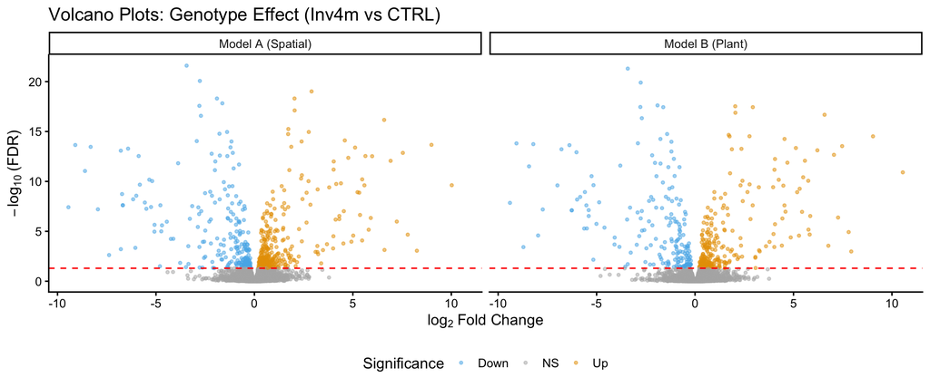

```r
# Prepare data for volcano plots
volcano_data <- bind_rows(
  results_spatial$genotype %>%
    mutate(model = "Model A (Spatial)", gene = rownames(results_spatial$genotype)),
  results_plant$genotype %>%
    mutate(model = "Model B (Plant)", gene = rownames(results_plant$genotype))
) %>%
  mutate(
    significance = case_when(
      adj.P.Val < 0.05 & logFC > 0 ~ "Up",
      adj.P.Val < 0.05 & logFC < 0 ~ "Down",
      TRUE ~ "NS"
    )
  )

p_volcano <- ggplot(volcano_data, aes(x = logFC, y = -log10(adj.P.Val))) +
  geom_point(aes(color = significance), alpha = 0.5, size = 1) +
  geom_hline(yintercept = -log10(0.05), linetype = "dashed", color = "red") +
  scale_color_manual(values = c("Down" = "#56B4E9", "NS" = "grey70", "Up" = "#E69F00")) +
  facet_wrap(~model, ncol = 2) +
  labs(
    title = "Volcano Plots: Genotype Effect (Inv4m vs CTRL)",
    x = expression(log[2] ~ "Fold Change"),
    y = expression(-log[10] ~ "(FDR)"),
    color = "Significance"
  ) +
  theme_classic(base_size = 14) +
  theme(legend.position = "bottom")

p_volcano
```

```r
ggsave(file.path(paths$figures, "volcano_genotype_comparison.pdf"),
       plot = p_volcano, width = 12, height = 5)
```

## SE Ratio Distribution

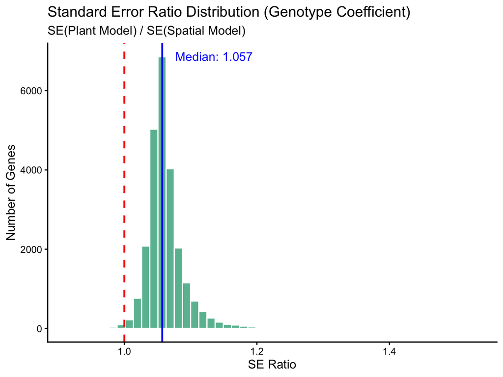

```r
p_se_ratio <- ggplot(se_comparison, aes(x = se_ratio)) +
  geom_histogram(bins = 50, fill = "#009E73", color = "white", alpha = 0.7) +
  geom_vline(xintercept = 1, linetype = "dashed", color = "red", linewidth = 1) +
  geom_vline(xintercept = median(se_comparison$se_ratio),
             linetype = "solid", color = "blue", linewidth = 1) +
  annotate("text", x = median(se_comparison$se_ratio) + 0.02, y = Inf,
           label = paste("Median:", round(median(se_comparison$se_ratio), 3)),
           vjust = 2, hjust = 0, color = "blue") +
  labs(
    title = "Standard Error Ratio Distribution (Genotype Coefficient)",
    subtitle = "SE(Plant Model) / SE(Spatial Model)",
    x = "SE Ratio",
    y = "Number of Genes"
  ) +
  theme_classic(base_size = 14)

p_se_ratio
```

```r
ggsave(file.path(paths$figures, "se_ratio_distribution.pdf"),
       plot = p_se_ratio, width = 8, height = 6)
```

## P-value Comparison

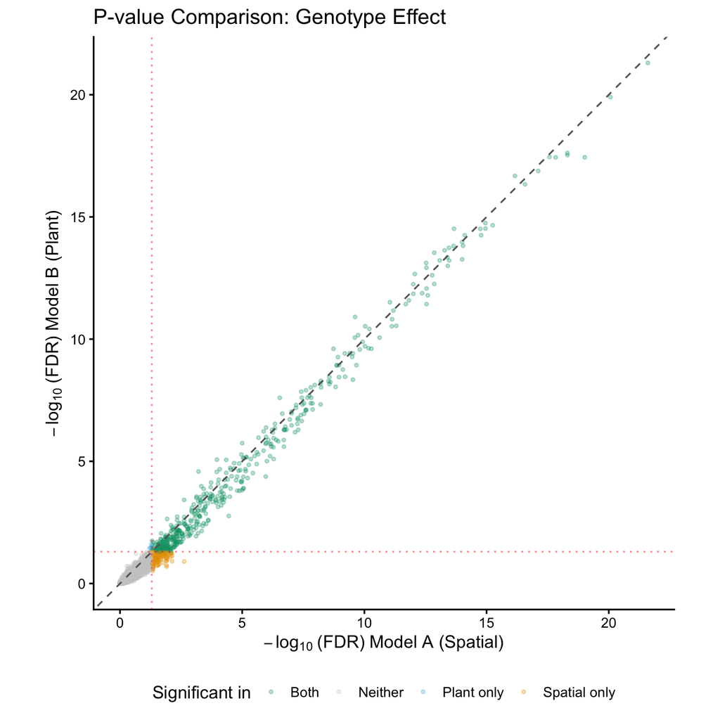

```r
pval_comparison <- tibble(
  gene = results_spatial$genotype$gene,
  neglogP_spatial = -log10(results_spatial$genotype$adj.P.Val),
  neglogP_plant = -log10(results_plant$genotype$adj.P.Val),
  sig_spatial = results_spatial$genotype$is_sig,
  sig_plant = results_plant$genotype$is_sig
) %>%
  mutate(
    category = case_when(
      sig_spatial & sig_plant ~ "Both",
      sig_spatial & !sig_plant ~ "Spatial only",
      !sig_spatial & sig_plant ~ "Plant only",
      TRUE ~ "Neither"
    )
  )

p_pval <- ggplot(pval_comparison, aes(x = neglogP_spatial, y = neglogP_plant)) +
  geom_point(aes(color = category), alpha = 0.3, size = 1) +
  geom_abline(slope = 1, intercept = 0, linetype = "dashed", color = "grey40") +
  geom_hline(yintercept = -log10(0.05), linetype = "dotted", color = "red", alpha = 0.5) +
  geom_vline(xintercept = -log10(0.05), linetype = "dotted", color = "red", alpha = 0.5) +
  scale_color_manual(values = c(
    "Both" = "#009E73",
    "Spatial only" = "#E69F00",
    "Plant only" = "#56B4E9",
    "Neither" = "grey80"
  )) +
  labs(
    title = "P-value Comparison: Genotype Effect",
    x = expression(-log[10] ~ "(FDR) Model A (Spatial)"),
    y = expression(-log[10] ~ "(FDR) Model B (Plant)"),
    color = "Significant in"
  ) +
  coord_fixed() +
  theme_classic(base_size = 14) +
  theme(legend.position = "bottom")

p_pval
```

```r
ggsave(file.path(paths$figures, "pvalue_comparison_scatterplot.pdf"),
       plot = p_pval, width = 8, height = 8)
```

# Export Gene Lists

```r
# Function to save gene lists
save_gene_list <- function(genes, filename, results_df = NULL) {
  if (length(genes) > 0 && !is.null(results_df)) {
    df <- results_df %>% filter(gene %in% genes)
  } else {
    df <- tibble(gene = genes)
  }
  write.csv(df, file.path(paths$intermediate, filename), row.names = FALSE)
  cat("Saved:", filename, "(", length(genes), "genes)\n")
}

cat("\n=== Exporting Gene Lists ===\n")
```

```
##
## === Exporting Gene Lists ===
```

```r
# Genotype effect
save_gene_list(
  intersect(sig_spatial$genotype, sig_plant$genotype),
  "deg_both_models_genotype.csv",
  results_spatial$genotype
)
```

```
## Saved: deg_both_models_genotype.csv ( 465 genes)
```

```r
save_gene_list(
  setdiff(sig_spatial$genotype, sig_plant$genotype),
  "deg_spatial_only_genotype.csv",
  results_spatial$genotype
)
```

```
## Saved: deg_spatial_only_genotype.csv ( 138 genes)
```

```r
save_gene_list(
  setdiff(sig_plant$genotype, sig_spatial$genotype),
  "deg_plant_only_genotype.csv",
  results_plant$genotype
)
```

```
## Saved: deg_plant_only_genotype.csv ( 5 genes)
```

```r
# Genotype:Treatment effect
save_gene_list(
  intersect(sig_spatial$genotype_trt, sig_plant$genotype_trt),
  "deg_both_models_genotype_trt.csv",
  results_spatial$genotype_trt
)
```

```
## Saved: deg_both_models_genotype_trt.csv ( 1 genes)
```

```r
save_gene_list(
  setdiff(sig_spatial$genotype_trt, sig_plant$genotype_trt),
  "deg_spatial_only_genotype_trt.csv",
  results_spatial$genotype_trt
)
```

```
## Saved: deg_spatial_only_genotype_trt.csv ( 2 genes)
```

```r
save_gene_list(
  setdiff(sig_plant$genotype_trt, sig_spatial$genotype_trt),
  "deg_plant_only_genotype_trt.csv",
  results_plant$genotype_trt
)
```

```
## Saved: deg_plant_only_genotype_trt.csv ( 0 genes)
```

```r
# Genotype:Leaf effect
save_gene_list(
  intersect(sig_spatial$genotype_leaf, sig_plant$genotype_leaf),
  "deg_both_models_genotype_leaf.csv",
  results_spatial$genotype_leaf
)
```

```
## Saved: deg_both_models_genotype_leaf.csv ( 1 genes)
```

```r
save_gene_list(
  setdiff(sig_spatial$genotype_leaf, sig_plant$genotype_leaf),
  "deg_spatial_only_genotype_leaf.csv",
  results_spatial$genotype_leaf
)
```

```
## Saved: deg_spatial_only_genotype_leaf.csv ( 1 genes)
```

```r
save_gene_list(
  setdiff(sig_plant$genotype_leaf, sig_spatial$genotype_leaf),
  "deg_plant_only_genotype_leaf.csv",
  results_plant$genotype_leaf
)
```

```
## Saved: deg_plant_only_genotype_leaf.csv ( 0 genes)
```

## Save Intermediate Objects

```r
# Save all comparison objects for later analysis
saveRDS(
  list(
    eb_spatial = eb_spatial,
    eb_plant = eb_plant,
    results_spatial = results_spatial,
    results_plant = results_plant,
    sig_spatial = sig_spatial,
    sig_plant = sig_plant,
    overlap_summary = overlap_summary,
    se_comparison = se_comparison,
    correlation_estimates = correlation_estimates
  ),
  file.path(paths$intermediate, "model_comparison_objects.rds")
)

cat("\nSaved: model_comparison_objects.rds\n")
```

```
##
## Saved: model_comparison_objects.rds
```

# Interpretation

## Summary Statistics

```r
cat("\n", paste(rep("=", 60), collapse = ""), "\n")
cat("MODEL COMPARISON SUMMARY\n")
```

```
## MODEL COMPARISON SUMMARY
```

```r
cat(paste(rep("=", 60), collapse = ""), "\n\n")
cat("1. CORRELATION STRUCTURE\n")
```

```
## 1. CORRELATION STRUCTURE
```

```r
cat("   - Spatial blocking correlation:",
    round(corfit_spatial$consensus.correlation, 4), "\n")
```

```
##    - Spatial blocking correlation: 0.1144
```

```r
cat("   - Plant blocking correlation:",
    round(corfit_plant$consensus.correlation, 4), "\n")
```

```
##    - Plant blocking correlation: 0.133
```

```r
if (corfit_plant$consensus.correlation > corfit_spatial$consensus.correlation) {
  cat("   -> Plant model captures higher within-block correlation\n\n")
} else {
  cat("   -> Spatial model captures higher within-block correlation\n\n")
}
```

```
##    -> Plant model captures higher within-block correlation
```

```r
cat("2. DEG DETECTION\n")
```

```
## 2. DEG DETECTION
```

```r
for (i in 1:nrow(comparison_counts)) {
  cat("   ", comparison_counts$coefficient[i], ":\n")
  cat("      Spatial:", comparison_counts$n_spatial[i], "DEGs\n")
  cat("      Plant:", comparison_counts$n_plant[i], "DEGs\n")
  cat("      Change:", comparison_counts$pct_change[i], "%\n")
}
```

```
##     Genotype :
##       Spatial: 603 DEGs
##       Plant: 470 DEGs
##       Change: -22.1 %
##     Genotype:Treatment :
##       Spatial: 3 DEGs
##       Plant: 1 DEGs
##       Change: -66.7 %
##     Genotype:Leaf :
##       Spatial: 2 DEGs
##       Plant: 1 DEGs
##       Change: -50 %
```

```r
cat("\n3. STANDARD ERROR INFLATION\n")
```

```
##
## 3. STANDARD ERROR INFLATION
```

```r
cat("   Median SE ratio (Plant/Spatial):",
    round(median(se_comparison$se_ratio), 3), "\n")
```

```
##    Median SE ratio (Plant/Spatial): 1.057
```

```r
if (median(se_comparison$se_ratio) > 1) {
  cat("   -> Plant model is more conservative (larger SEs)\n")
} else {
  cat("   -> Spatial model is more conservative (larger SEs)\n")
}
```

```
##    -> Plant model is more conservative (larger SEs)
```

```r
cat("\n4. OVERLAP ANALYSIS\n")
```

```
##
## 4. OVERLAP ANALYSIS
```

```r
for (i in 1:nrow(overlap_summary)) {
  cat("   ", overlap_summary$coefficient[i], ":\n")
  cat("      Jaccard index:", round(overlap_summary$jaccard[i], 3), "\n")
  cat("      Both models:", overlap_summary$n_both[i], "genes\n")
  cat("      Spatial only:", overlap_summary$n_spatial_only[i], "genes\n")
  cat("      Plant only:", overlap_summary$n_plant_only[i], "genes\n")
}
```

```
##     Genotype :
##       Jaccard index: 0.765
##       Both models: 465 genes
##       Spatial only: 138 genes
##       Plant only: 5 genes
##     Genotype:Treatment :
##       Jaccard index: 0.333
##       Both models: 1 genes
##       Spatial only: 2 genes
##       Plant only: 0 genes
##     Genotype:Leaf :
##       Jaccard index: 0.5
##       Both models: 1 genes
##       Spatial only: 1 genes
##       Plant only: 0 genes
```

## Interpretation Guidelines

Based on the handover document:

```r
# Determine interpretation based on results
pct_reduction_genotype <- comparison_counts$pct_change[1]
plant_cor <- corfit_plant$consensus.correlation

cat("\n", paste(rep("=", 60), collapse = ""), "\n")
cat("INTERPRETATION\n")
```

```
## INTERPRETATION
```

```r
cat(paste(rep("=", 60), collapse = ""), "\n\n")
if (pct_reduction_genotype < -30) {
  cat("FINDING: Model B detects substantially fewer DEGs (",
      abs(pct_reduction_genotype), "% reduction)\n\n")
  cat("INTERPRETATION: Within-plant leaf correlation was substantial.\n")
  cat("Model A was anti-conservative, treating pseudo-replicates as independent.\n")
  cat("Model B provides correct inference.\n\n")
  cat("RECOMMENDATION: Adopt Model B (plant blocking) for publication.\n")
} else if (abs(pct_reduction_genotype) < 10) {
  cat("FINDING: Both models detect similar numbers of DEGs\n\n")
  cat("INTERPRETATION: Within-plant correlation is modest or well-handled\n")
  cat("by both blocking approaches.\n\n")
  cat("RECOMMENDATION: Either model is acceptable. Consider biological\n")
  cat("interpretation for final choice.\n")
} else {
  cat("FINDING: Models show moderate differences in DEG detection\n\n")
  cat("INTERPRETATION: Blocking structure matters for inference.\n")
  cat("Examine genes unique to each model for biological plausibility.\n")
}
```

```
## FINDING: Models show moderate differences in DEG detection
##
## INTERPRETATION: Blocking structure matters for inference.
## Examine genes unique to each model for biological plausibility.
```

```r
if (plant_cor > 0.5) {
  cat("\nNOTE: High within-plant correlation (rho =", round(plant_cor, 3), ")\n")
  cat("strongly supports using Model B (plant blocking).\n")
}
```